# An RMarkdown version of the .r file

John & Joel

August 27, 2016

This is a Thought Bucket -Test Run The follow is a test Rmd file to test suitability for an introductory workshop in R. This is the first .Rmd version based on a [document](https://docs.google.com/document/d/1FUdzDSje_b-0n0fxNrrXiJ11kUC5sNzhYdYmyXu_GFU/edit) Joel & I are working on.

## Workshop Outline

===================================================================================================

## Identify Library Packages

First I’m going to load all the packages I use for this tutorial. Strictly speaking this is a two step process: (1) install the package; (2) load the package. I’ll include the install commands for [reproducibility](https://en.wikipedia.org/wiki/Reproducibility), but you can probably skip to simply loading the packages. If any library library doesn’t load you can uncomment the “install.packages” command; simply remove the # in front of the relevant “intall.packages”. Then rerun the relevant install commands followed the relvant load commands.

A **note** about the number of packages. You **don’t need all** of the packages. Some packages are a convenience for me as an instructor. The necessary packages are **readxl**, **readr**, **dplyr**, and **ggplot2**.

```r
# If you do not have these packages already loaded in your packages list, you can install them by uncommenting the following lines.
# install.packages("readxl")
# install.packages("readr")
# install.packages("dplyr")
# install.packages("ggplot2")
# install.packages("stringr")
# install.packages("stringi")


# packages required for this workshop
library(readxl)     # import Excel files into R - https://github.com/hadley/readxl
library(readr)      # read tabular data into R - https://github.com/hadley/readr
library(dplyr)      # working with data frames - https://github.com/hadley/dplyr
library(ggplot2)    # popular visualization package - https://github.com/hadley/ggplot2
# library(stringr)
# library(striingi)

# Optional Library Packages
# install.packages("rmarkdown")
library(rmarkdown)  # R specific implementation for markdown - https://github.com/hadley/rmarkdown
```

===================================================================================================

# Intro to R

## Data Structre Types

As you can see the object orientation of R allows you to be specific about objects characteristics. These characteristics are called [Data Types](http://venus.ifca.unican.es/Rintro/dataStruct.html) or Data Structures. This specificity can yield a sophisticated outcome but it may lead to confusion for those learning R. For this workshop we’ll stick with two very common data types: **Vectors** and **Data Frames**

- **Vectors** are one dimentional arrays which must be all of the same mode: *Numeric*, *Complex*, *Logical*, or *Character*
- *Factors* are vectors used when working with [categorical variables](https://en.wikipedia.org/wiki/Categorical_variable)
- **Data Frames** are generalized matricies. Different columns can store different types including vectors, lists, Factors, Arrays, and Functions.

For now, remember you can only store one data type in a Vector *but* you can store multipe vector types in a data frame. But I encourage you to read more about [Data Types](http://venus.ifca.unican.es/Rintro/dataStruct.html), later.

===================================================================================================

## Variable Assignment

You can assign variable or object names, most commonly using the *<-* operator but there are many equivalent assignment operators

- Assignment Operators
  - <<-
  - <-
  - =
  - ->
  - ->>

```r
# Assign "foo" as a three item character vector:
foo <- c("apple", "bannana", "grape")
foo ->> bar

# now recall those objects by name:
foo
```

```
## [1] "apple"   "bannana" "grape"
```

```r
bar
```

```
## [1] "apple"   "bannana" "grape"
```

===================================================================================================

## Data Management

### Download some sample data

1. Download the [UnempData.xlsx](http://foo.com) file to your download directory.
2. Move that file to your working directory as identified by the command `getwd()`
3. Now Load that using assignments and the `read_excel` function

Where will R look for your data? Identify the R’s default data directory.

```r
getwd()
```

```
## [1] "C:/Users/john/Documents/R Projects/bitbucket_git_dir/devbb"
```

- You can change the workding directory using setwd()
  - setwd(“c:/somedir/”)

### Tell R to load your data

#### Use assignment operators to construct filepath/filename

e.g. to read data into a dataframe

```r
DIR <- getwd()
filename <- "UnempData.xlsx"
fullpath <- paste(DIR, "/", filename, sep = '')
# See value of the constructed character vector
fullpath
```

```
## [1] "C:/Users/john/Documents/R Projects/bitbucket_git_dir/devbb/UnempData.xlsx"
```

```r
#display the value of fullpath in the console
```

### Load an excel file (read_excel from readxl package)

```r
# read the downloaded excel file into a data frame
# use the read_excel() function, part of the readxl() package loaded earlier
# To get help using read_excel() type the following into the console:  ?read_excel   [Enter]
unempdata <- read_excel(fullpath)
```

#### Honorable Mention Data Loaders

- foreign - load data from SPSS, SAS, and other Statistical Analysis applicatons
- googlesheets - load data from Google Sheets

===================================================================================================

## Identify And Display descriptive characteristics of data objects

There are various ways to view the data objects in R

### Displays your data in a grid style within the “Source”" pane

```r
View(unempdata)
```

### Identify the data variable characteristics of the data object

```r
class(unempdata)
```

```
## [1] "tbl_df"     "tbl"        "data.frame"
```

### Identify the dimentions of the data object

```r
dim(unempdata)
```

```
## [1] 104   6
```

### Identify the number of rows in the data object

```r
nrow(unempdata)
```

```
## [1] 104
```

### Identify the number of columns in the data object

```r
ncol(unempdata)
```

```
## [1] 6
```

### Identify the structure of the data object

```r
str(unempdata)
```

```
## Classes 'tbl_df', 'tbl' and 'data.frame':    104 obs. of  6 variables:
##  $ ID                                      : chr  "0001" "0002" "0003" "0004" ...
##  $  recode: any employment discrimination  : chr  "Yes" "Yes" "Yes" "Yes" ...
##  $ lost my job                             : chr  "No" "No" "No" "No" ...
##  $ underemployed                           : chr  "No" "No" "No" "No" ...
##  $ removed from direct contact with clients: chr  "No" "Yes" "No" "No" ...
##  $ denied a promotion                      : chr  "No" "No" "No" "Yes" ...
```

### Identify the top rows of the data object

```r
head(unempdata)
```

```
## # A tibble: 6 x 6
##      ID  recode: any employment discrimination  lost my job underemployed
##   <chr>                                   <chr>       <chr>         <chr>
## 1  0001                                     Yes          No            No
## 2  0002                                     Yes          No            No
## 3  0003                                     Yes          No            No
## 4  0004                                     Yes          No            No
## 5  0005                                     Yes          No            No
## 6  0006                                     Yes          No           Yes
## # ... with 2 more variables: removed from direct contact with
## #   clients <chr>, denied a promotion  <chr>
```

### Identify the botom twenty rows of the data object

```r
tail(unempdata, 20)
```

```
## # A tibble: 20 x 6
##       ID  recode: any employment discrimination     lost my job
##    <chr>                                   <chr>          <chr>
## 1   0085                                     Yes Not Applicable
## 2   0086                                     Yes             No
## 3   0087                                     Yes Not Applicable
## 4   0088                                     Yes             No
## 5   0089                                     Yes             No
## 6   0090                                     Yes             No
## 7   0091                                     Yes             No
## 8   0092                                     Yes             No
## 9   0093                                     Yes             No
## 10  0094                                     Yes            Yes
## 11  0095                                     Yes            Yes
## 12  0096                                     Yes            Yes
## 13  0097                                     Yes             No
## 14  0098                                     Yes             No
## 15  0099                                     Yes             No
## 16  0100                                     Yes             No
## 17  0101                                     Yes             No
## 18  0102                                     Yes             No
## 19  0103                                     Yes             No
## 20  0104                                     Yes             No
## # ... with 3 more variables: underemployed <chr>, removed from direct
## #   contact with clients <chr>, denied a promotion  <chr>
```

### Identify a statistical summary of the data object

```r
summary(unempdata)
```

```
##       ID             recode: any employment discrimination
##  Length:104         Length:104
##  Class :character   Class :character
##  Mode  :character   Mode  :character
##  lost my job        underemployed
##  Length:104         Length:104
##  Class :character   Class :character
##  Mode  :character   Mode  :character
##  removed from direct contact with clients denied a promotion
##  Length:104                               Length:104
##  Class :character                         Class :character
##  Mode  :character                         Mode  :character
```

==============================================================================

## Use the dplyr packge for some data frame manipulation aka Data Wrangling

```r
# library(dplyr)  # this library packaged was loaded earlier
tbl_df(unempdata)
```

```
## # A tibble: 104 x 6
##       ID  recode: any employment discrimination     lost my job
##    <chr>                                   <chr>          <chr>
## 1   0001                                     Yes             No
## 2   0002                                     Yes             No
## 3   0003                                     Yes             No
## 4   0004                                     Yes             No
## 5   0005                                     Yes             No
## 6   0006                                     Yes             No
## 7   0007                                     Yes             No
## 8   0008                                     Yes Not Applicable
## 9   0009                                     Yes             No
## 10  0010                                     Yes             No
## # ... with 94 more rows, and 3 more variables: underemployed <chr>,
## #   removed from direct contact with clients <chr>, denied a promotion
## #    <chr>
```

### Change colunn header

```r
colnames(unempdata)     # identify the existing column names
```

```
## [1] "ID"
## [2] " recode: any employment discrimination "
## [3] "lost my job"
## [4] "underemployed"
## [5] "removed from direct contact with clients"
## [6] "denied a promotion "
```

```r
unempdata <- rename(unempdata, discriminate = ` recode: any employment discrimination `, no_job = `lost my job`, no_clients = `removed from direct contact with clients`, promotion = `denied a promotion `)            # rename column names


colnames(unempdata)     # Proof that the names where changed by using the reassignment operator
```

```
## [1] "ID"            "discriminate"  "no_job"        "underemployed"
## [5] "no_clients"    "promotion"
```

### Recode

- Use *Recode* to change the values and supply the NA Characteristics
  - Replace “Not Applicable” with “NA”)
- Change the character vector to a logical vector

```r
unempdata$no_job <- recode(unempdata$no_job, No = "FALSE", Yes = "TRUE", "Not Applicable" = NA_character_)
```

```r
class(unempdata$no_job)
```

```
## [1] "character"
```

```r
unempdata$no_job <- as.logical(unempdata$no_job)
tbl_df(unempdata)
```

```
## # A tibble: 104 x 6
##       ID discriminate no_job  underemployed     no_clients      promotion
##    <chr>        <chr>  <lgl>          <chr>          <chr>          <chr>
## 1   0001          Yes  FALSE             No             No             No
## 2   0002          Yes  FALSE             No            Yes             No
## 3   0003          Yes  FALSE             No             No             No
## 4   0004          Yes  FALSE             No             No            Yes
## 5   0005          Yes  FALSE             No             No             No
## 6   0006          Yes  FALSE            Yes             No             No
## 7   0007          Yes  FALSE             No             No             No
## 8   0008          Yes     NA Not Applicable Not Applicable Not Applicable
## 9   0009          Yes  FALSE             No             No            Yes
## 10  0010          Yes  FALSE            Yes             No             No
## # ... with 94 more rows
```

```r
summary(unempdata)
```

```
##       ID            discriminate         no_job        underemployed
##  Length:104         Length:104         Mode :logical   Length:104
##  Class :character   Class :character   FALSE:65        Class :character
##  Mode  :character   Mode  :character   TRUE :14        Mode  :character
##                                        NA's :25
##   no_clients         promotion
##  Length:104         Length:104
##  Class :character   Class :character
##  Mode  :character   Mode  :character
##
```

### FILTER

```r
data("mtcars")      #load the onboard mtcars dataset, part of base R
View(mtcars)
```

```r
four.six <- filter(mtcars, mtcars$cyl <8)      #filter out 8 cylinder cars and make a new data.frame "four.six"
tbl_df(four.six)                               #Alas!  now rownames
```

```
## # A tibble: 18 x 11
##      mpg   cyl  disp    hp  drat    wt  qsec    vs    am  gear  carb
##    <dbl> <dbl> <dbl> <dbl> <dbl> <dbl> <dbl> <dbl> <dbl> <dbl> <dbl>
## 1   21.0     6 160.0   110  3.90 2.620 16.46     0     1     4     4
## 2   21.0     6 160.0   110  3.90 2.875 17.02     0     1     4     4
## 3   22.8     4 108.0    93  3.85 2.320 18.61     1     1     4     1
## 4   21.4     6 258.0   110  3.08 3.215 19.44     1     0     3     1
## 5   18.1     6 225.0   105  2.76 3.460 20.22     1     0     3     1
## 6   24.4     4 146.7    62  3.69 3.190 20.00     1     0     4     2
## 7   22.8     4 140.8    95  3.92 3.150 22.90     1     0     4     2
## 8   19.2     6 167.6   123  3.92 3.440 18.30     1     0     4     4
## 9   17.8     6 167.6   123  3.92 3.440 18.90     1     0     4     4
## 10  32.4     4  78.7    66  4.08 2.200 19.47     1     1     4     1
## 11  30.4     4  75.7    52  4.93 1.615 18.52     1     1     4     2
## 12  33.9     4  71.1    65  4.22 1.835 19.90     1     1     4     1
## 13  21.5     4 120.1    97  3.70 2.465 20.01     1     0     3     1
## 14  27.3     4  79.0    66  4.08 1.935 18.90     1     1     4     1
## 15  26.0     4 120.3    91  4.43 2.140 16.70     0     1     5     2
## 16  30.4     4  95.1   113  3.77 1.513 16.90     1     1     5     2
## 17  19.7     6 145.0   175  3.62 2.770 15.50     0     1     5     6
## 18  21.4     4 121.0   109  4.11 2.780 18.60     1     1     4     2
```

```r
four.six <- mutate(mtcars, rownames(mtcars))                #add the row names as a separate column
four.six <- rename(four.six, makeModel = `rownames(mtcars)`)     #rename the auto-named added column
four.six <- select(four.six, makeModel, mpg:wt)                  #select the columns wanted
four.six <- filter(four.six, cyl >= 4, cyl <=6)
four.six <- mutate(four.six,
  wtdisp = wt / disp
)
tbl_df(four.six)
```

```
## # A tibble: 18 x 8
##         makeModel   mpg   cyl  disp    hp  drat    wt     wtdisp
##             <chr> <dbl> <dbl> <dbl> <dbl> <dbl> <dbl>      <dbl>
## 1       Mazda RX4  21.0     6 160.0   110  3.90 2.620 0.01637500
## 2   Mazda RX4 Wag  21.0     6 160.0   110  3.90 2.875 0.01796875
## 3      Datsun 710  22.8     4 108.0    93  3.85 2.320 0.02148148
## 4  Hornet 4 Drive  21.4     6 258.0   110  3.08 3.215 0.01246124
## 5         Valiant  18.1     6 225.0   105  2.76 3.460 0.01537778
## 6       Merc 240D  24.4     4 146.7    62  3.69 3.190 0.02174506
## 7        Merc 230  22.8     4 140.8    95  3.92 3.150 0.02237216
## 8        Merc 280  19.2     6 167.6   123  3.92 3.440 0.02052506
## 9       Merc 280C  17.8     6 167.6   123  3.92 3.440 0.02052506
## 10       Fiat 128  32.4     4  78.7    66  4.08 2.200 0.02795426
## 11    Honda Civic  30.4     4  75.7    52  4.93 1.615 0.02133421
## 12 Toyota Corolla  33.9     4  71.1    65  4.22 1.835 0.02580872
## 13  Toyota Corona  21.5     4 120.1    97  3.70 2.465 0.02052456
## 14      Fiat X1-9  27.3     4  79.0    66  4.08 1.935 0.02449367
## 15  Porsche 914-2  26.0     4 120.3    91  4.43 2.140 0.01778886
## 16   Lotus Europa  30.4     4  95.1   113  3.77 1.513 0.01590957
## 17   Ferrari Dino  19.7     6 145.0   175  3.62 2.770 0.01910345
## 18     Volvo 142E  21.4     4 121.0   109  4.11 2.780 0.02297521
```

```r
arrange(four.six, cyl, desc(mpg), desc(hp), wt, wtdisp)
```

```
##         makeModel  mpg cyl  disp  hp drat    wt     wtdisp
## 1  Toyota Corolla 33.9   4  71.1  65 4.22 1.835 0.02580872
## 2        Fiat 128 32.4   4  78.7  66 4.08 2.200 0.02795426
## 3    Lotus Europa 30.4   4  95.1 113 3.77 1.513 0.01590957
## 4     Honda Civic 30.4   4  75.7  52 4.93 1.615 0.02133421
## 5       Fiat X1-9 27.3   4  79.0  66 4.08 1.935 0.02449367
## 6   Porsche 914-2 26.0   4 120.3  91 4.43 2.140 0.01778886
## 7       Merc 240D 24.4   4 146.7  62 3.69 3.190 0.02174506
## 8        Merc 230 22.8   4 140.8  95 3.92 3.150 0.02237216
## 9      Datsun 710 22.8   4 108.0  93 3.85 2.320 0.02148148
## 10  Toyota Corona 21.5   4 120.1  97 3.70 2.465 0.02052456
## 11     Volvo 142E 21.4   4 121.0 109 4.11 2.780 0.02297521
## 12 Hornet 4 Drive 21.4   6 258.0 110 3.08 3.215 0.01246124
## 13      Mazda RX4 21.0   6 160.0 110 3.90 2.620 0.01637500
## 14  Mazda RX4 Wag 21.0   6 160.0 110 3.90 2.875 0.01796875
## 15   Ferrari Dino 19.7   6 145.0 175 3.62 2.770 0.01910345
## 16       Merc 280 19.2   6 167.6 123 3.92 3.440 0.02052506
## 17        Valiant 18.1   6 225.0 105 2.76 3.460 0.01537778
## 18      Merc 280C 17.8   6 167.6 123 3.92 3.440 0.02052506
```

```r
library(stringr)
four.six$make <- word(four.six$makeModel, 1)
# str_extract(four.six$makeModel, "\\w+\\s(.*)")

library(stringi)
# stri_match_all_regex(four.six$makeModel, "\\w+\\s(.*)")[[1]][2]
# stri_match_last_regex(four.six$makeModel, "\\w+\\s(.*)",)[,2]
# stri_match_last_regex(four.six$makeModel, "\\w+\\s(.*)", cg_missing = "")[,2]
four.six$model <- stri_match_last_regex(four.six$makeModel, "\\w+\\s(.*)", cg_missing = "")[,2]
```

## Table Summaries

```r
# then folloing from ...
# R Tutorial by Kelly Black is licensed under a Creative Commons Attribution-NonCommercial 4.0 International License (2015).
# http://www.cyclismo.org/tutorial/R/tables.html#graphical-views-of-tables
smokerdata <- read_csv("http://www.cyclismo.org/tutorial/R/_static/smoker.csv")
tbl_df(smokerdata)
```

```
## # A tibble: 356 x 2
##     Smoke   SES
##     <chr> <chr>
## 1  former  High
## 2  former  High
## 3  former  High
## 4  former  High
## 5  former  High
## 6  former  High
## 7  former  High
## 8  former  High
## 9  former  High
## 10 former  High
## # ... with 346 more rows
```

```r
unique(smokerdata$Smoke)
```

```
## [1] "former"  "current" "never"
```

```r
unique(smokerdata$SES)
```

```
## [1] "High"   "Middle" "Low"
```

```r
table(smokerdata)
```

```
##          SES
## Smoke     High Low Middle
##   current   51  43     22
##   former    92  28     21
##   never     68  22      9
```

```r
table(smokerdata$Smoke)
```

```
##
## current  former   never
##     116     141      99
```

## Visualizations

### Scatter Plot

```r
data("iris")
tbl_df(iris)
```

```
## # A tibble: 150 x 5
##    Sepal.Length Sepal.Width Petal.Length Petal.Width Species
##           <dbl>       <dbl>        <dbl>       <dbl>  <fctr>
## 1           5.1         3.5          1.4         0.2  setosa
## 2           4.9         3.0          1.4         0.2  setosa
## 3           4.7         3.2          1.3         0.2  setosa
## 4           4.6         3.1          1.5         0.2  setosa
## 5           5.0         3.6          1.4         0.2  setosa
## 6           5.4         3.9          1.7         0.4  setosa
## 7           4.6         3.4          1.4         0.3  setosa
## 8           5.0         3.4          1.5         0.2  setosa
## 9           4.4         2.9          1.4         0.2  setosa
## 10          4.9         3.1          1.5         0.1  setosa
## # ... with 140 more rows
```

```r
table(iris$Species, iris$Petal.Width)
```

```
##
##              0.1 0.2 0.3 0.4 0.5 0.6  1 1.1 1.2 1.3 1.4 1.5 1.6 1.7 1.8
##   setosa       5  29   7   7   1   1  0   0   0   0   0   0   0   0   0
##   versicolor   0   0   0   0   0   0  7   3   5  13   7  10   3   1   1
##   virginica    0   0   0   0   0   0  0   0   0   0   1   2   1   1  11
##
##              1.9  2 2.1 2.2 2.3 2.4 2.5
##   setosa       0  0   0   0   0   0   0
##   versicolor   0  0   0   0   0   0   0
##   virginica    5  6   6   3   8   3   3
```

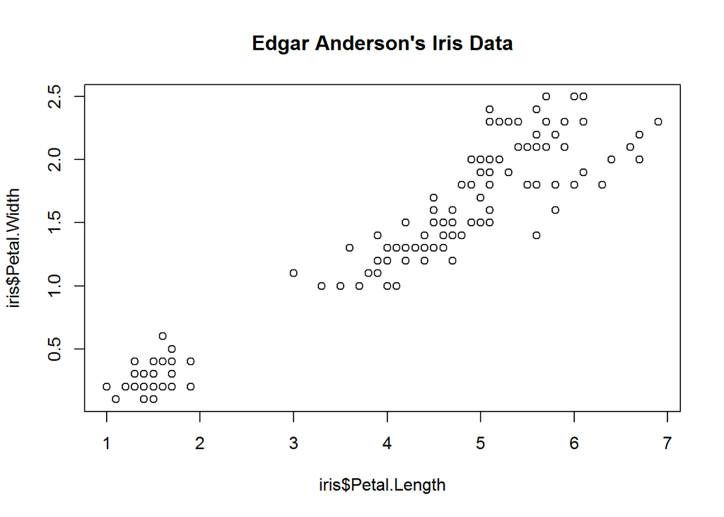

```r
# scatter plot
# http://www2.warwick.ac.uk/fac/sci/moac/people/students/peter_cock/r/iris_plots/
plot(iris$Petal.Length, iris$Petal.Width, main="Edgar Anderson's Iris Data")
```

### Histogram

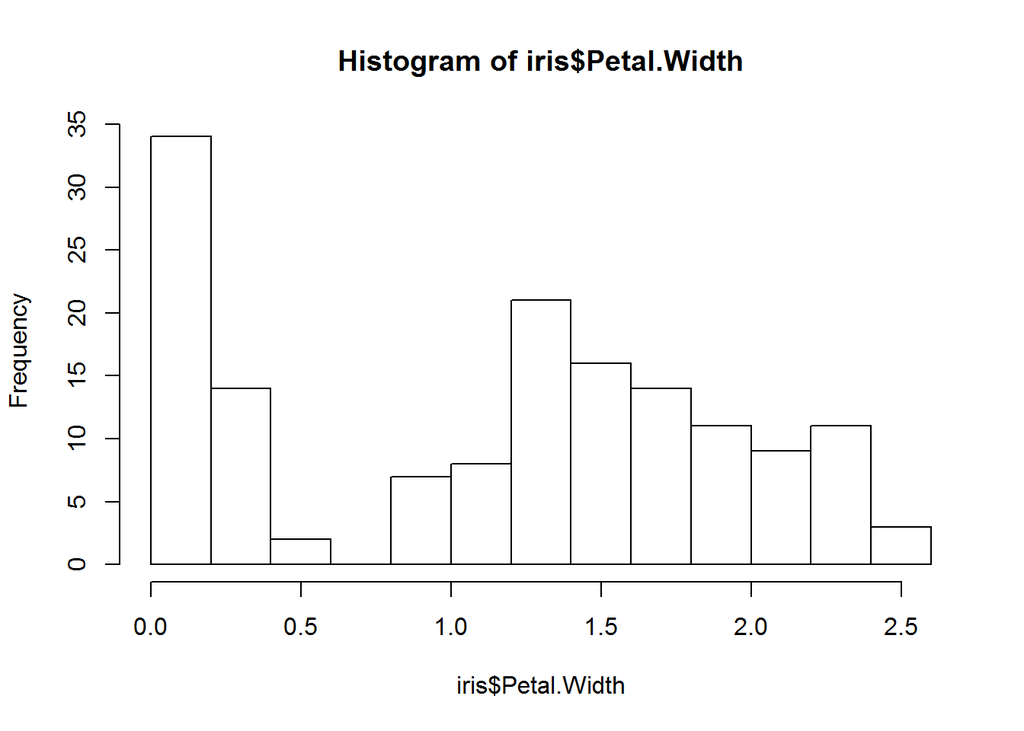

```r
hist(iris$Petal.Width)
```

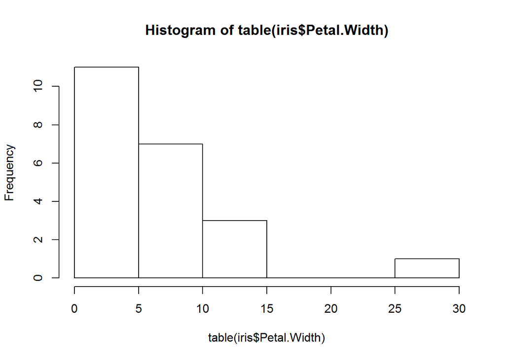

```r
hist(table(iris$Petal.Width))
```

### Bar Plot

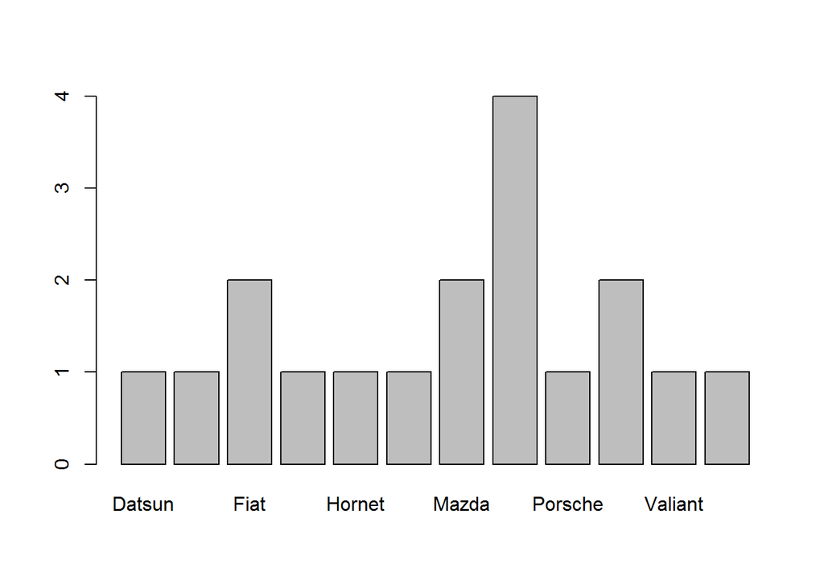

```r
# for categorical
barplot(table(four.six$make))
```

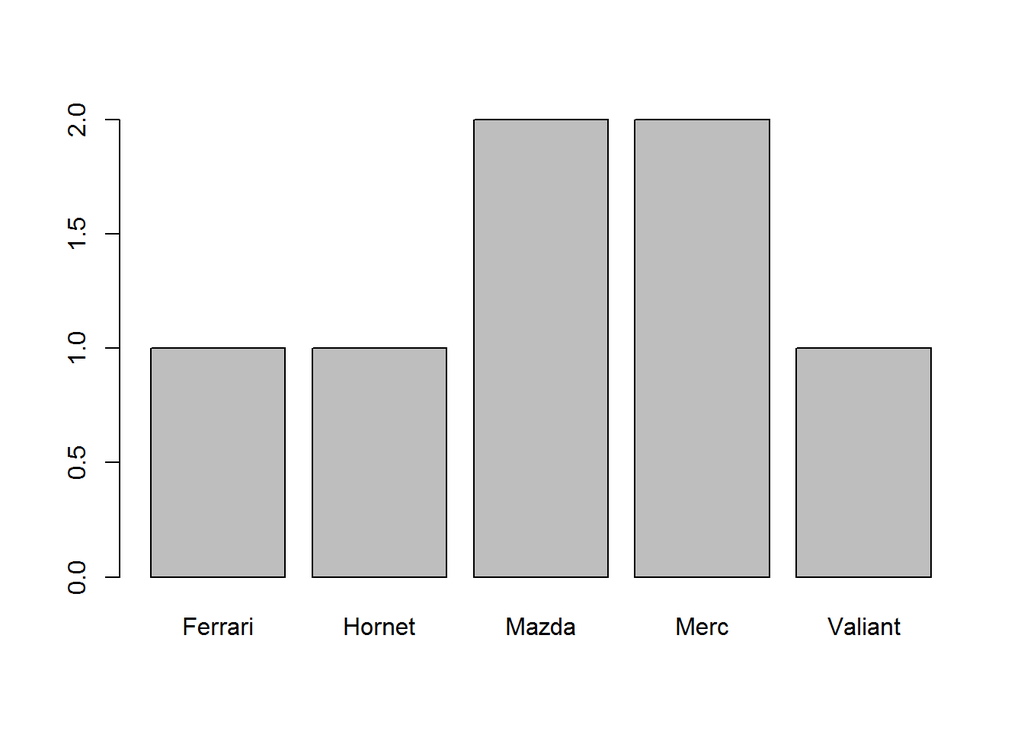

```r
sixcyls <- filter(four.six, cyl == 6)
barplot(table(sixcyls$make))
```

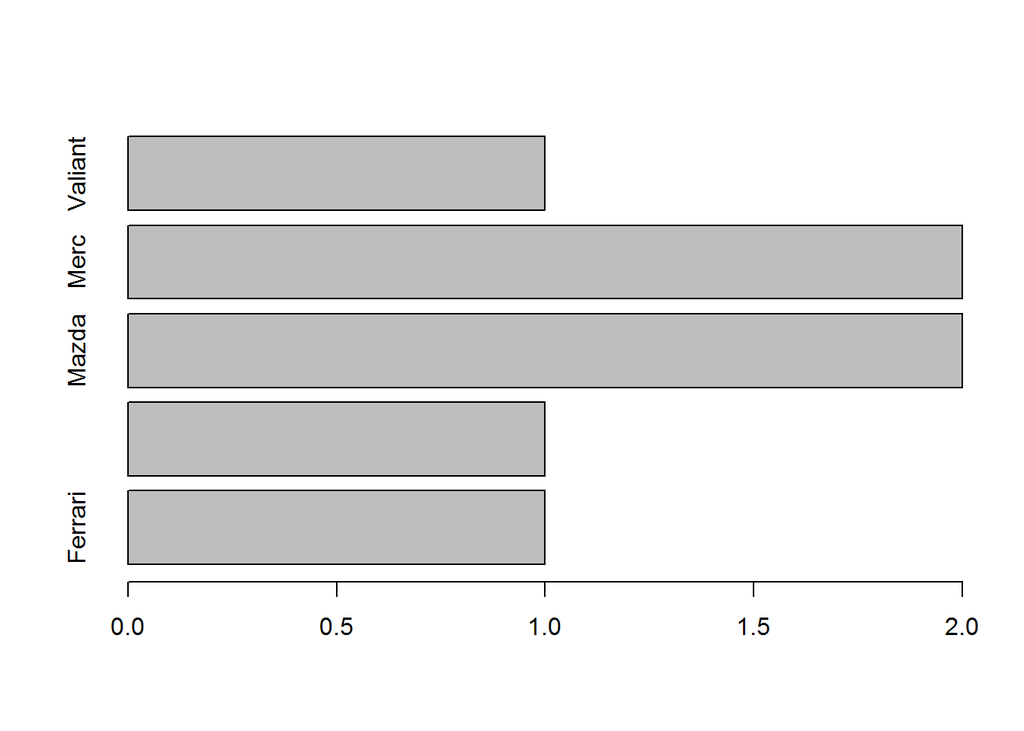

```r
barplot(table(sixcyls$make), horiz = TRUE)
```

### Mosaic Plot

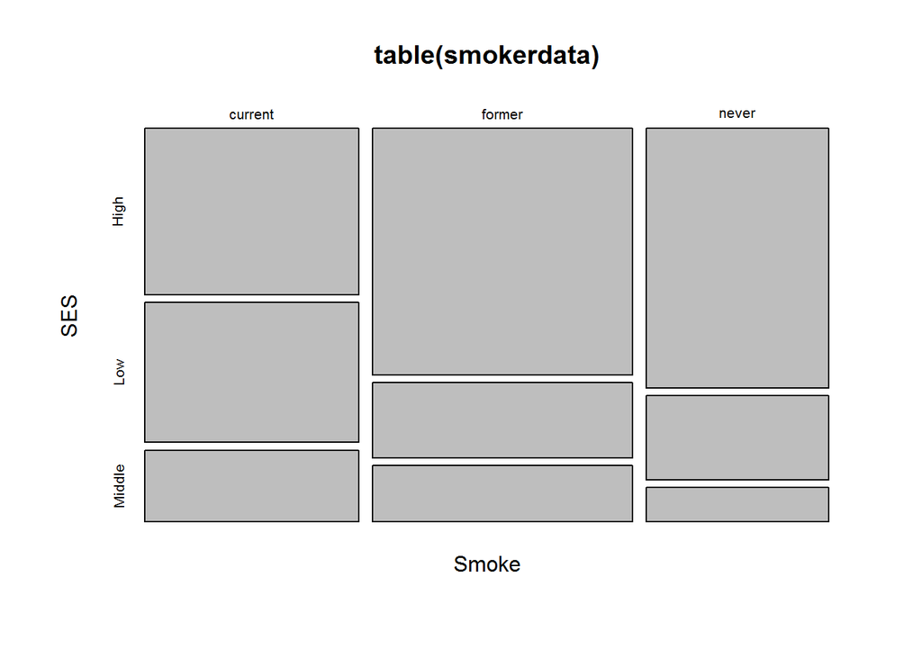

```r
mosaicplot(table(smokerdata))
```

## String Manipuation

Use stringr - https://github.com/hadley/stringr

```r
library(stringr)
four.six$make <- word(four.six$makeModel, 1)
# str_extract(four.six$makeModel, "\\w+\\s(.*)")

library(stringi)
# stri_match_all_regex(four.six$makeModel, "\\w+\\s(.*)")[[1]][2]
# stri_match_last_regex(four.six$makeModel, "\\w+\\s(.*)",)[,2]
# stri_match_last_regex(four.six$makeModel, "\\w+\\s(.*)", cg_missing = "")[,2]
four.six$model <- stri_match_last_regex(four.six$makeModel, "\\w+\\s(.*)", cg_missing = "")[,2]
```

> render(“fifthPass.Rmd”, output_file = ‘Intro2R.html’, output_dir = “output” )